# projekt

Tytuł projektu: *"Analiza Zależności Cen Akcji Tesli od Cen Ropy Naftowej i Gazu Ziemnego w Latach 2018-2024"*

Autorzy: Katarzyna Zyśko (101027), Zuzanna Winiarska (101020)

Grupa laboratoryjna: 02

**Wprowadzenie**

Celem tego projektu jest zbadanie potencjalnych zależności między cenami akcji Tesli a cenami ropy naftowej i gazu ziemnego. Analiza obejmuje przygotowanie danych, wizualizację danych za pomocą histogramów i funkcji gęstości, obliczenie podstawowych statystyk, przeprowadzenie regresji liniowej oraz analizę składników reszt.

```python
import yfinance as yf
import pandas as pd
import matplotlib.pyplot as plt
import seaborn as sns
from statsmodels.distributions.empirical_distribution import ECDF
import statsmodels.api as sm
from scipy.stats import shapiro
```

**Przygotowanie danych**

Dane dotyczące cen akcji Tesli (TSLA), ropy naftowej (CL=F) i gazu ziemnego (NG=F) zostały pobrane z serwisu Yahoo Finance za okres od 1 stycznia 2018 roku do 6 czerwca 2024 roku. Dane zostały zsynchronizowane według dat i przetworzone, aby usunąć brakujące wartości.

```python
tesla = yf.download(tickers='TSLA', start='2018-01-01', end='2024-06-06')
oil = yf.download(tickers='CL=F', start='2018-01-01', end='2024-06-06')
gas = yf.download(tickers='NG=F', start='2018-01-01', end='2024-06-06')
```

```
[*********************100%%**********************]  1 of 1 completed
[*********************100%%**********************]  1 of 1 completed
[*********************100%%**********************]  1 of 1 completed
```

```python
data = pd.DataFrame({
    'Tesla_High': tesla['High'],
    'Oil_High': oil['High'],
    'Gas_High': gas['High']
}).dropna()
```

```python
data.head()
```

| Date | Tesla_High | Oil_High | Gas_High |
| --- | --- | --- | --- |
| 2018-01-02 | 21.474001 | 60.740002 | 3.097 |
| 2018-01-03 | 21.683332 | 61.970001 | 3.056 |
| 2018-01-04 | 21.236668 | 62.209999 | 3.070 |
| 2018-01-05 | 21.149332 | 62.040001 | 2.887 |
| 2018-01-08 | 22.468000 | 61.970001 | 2.869 |

```python
tesla.head()
```

| Date | Open | High | Low | Close | Adj Close | Volume |
| --- | --- | --- | --- | --- | --- | --- |
| 2018-01-02 | 20.799999 | 21.474001 | 20.733334 | 21.368668 | 21.368668 | 65283000 |
| 2018-01-03 | 21.400000 | 21.683332 | 21.036667 | 21.150000 | 21.150000 | 67822500 |
| 2018-01-04 | 20.858000 | 21.236668 | 20.378668 | 20.974667 | 20.974667 | 149194500 |
| 2018-01-05 | 21.108000 | 21.149332 | 20.799999 | 21.105333 | 21.105333 | 68868000 |
| 2018-01-08 | 21.066668 | 22.468000 | 21.033333 | 22.427334 | 22.427334 | 147891000 |

**Wizualizacja danych**

Aby lepiej zrozumieć rozkład cen, wykonano histogramy i funkcje gęstości dla każdej z analizowanych cech:

- Ceny najwyższej akcji Tesli
- Ceny najwyższej ropy naftowej
- Ceny najwyższej gazu ziemnego

Dodatkowo, przedstawiono Empiryczne Funkcje Dystrybuant (ECDF) dla każdej z cech, aby zobrazować skumulowany rozkład cen.

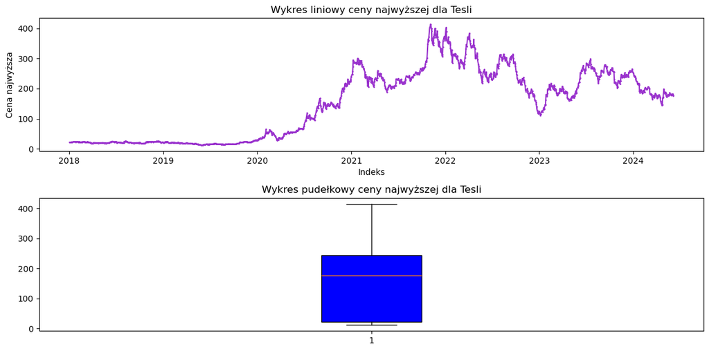

```python
plt.figure(figsize=(12,6))

# Wykres liniowy
plt.subplot(211)
plt.plot(tesla.High, color='#9932CD', linestyle='-', marker='o', markersize=1) # Dodanie koloru, stylu linii i markerów
plt.title('Wykres liniowy ceny najwyższej dla Tesli')
plt.xlabel('Indeks')
plt.ylabel('Cena najwyższa')

# Wykres pudełkowy
plt.subplot(212)
plt.boxplot(tesla.High, patch_artist=True, boxprops=dict(facecolor='#0000FF')) # Zmiana koloru pudełek i tła
plt.title('Wykres pudełkowy ceny najwyższej dla Tesli')

plt.tight_layout()
plt.show()
```

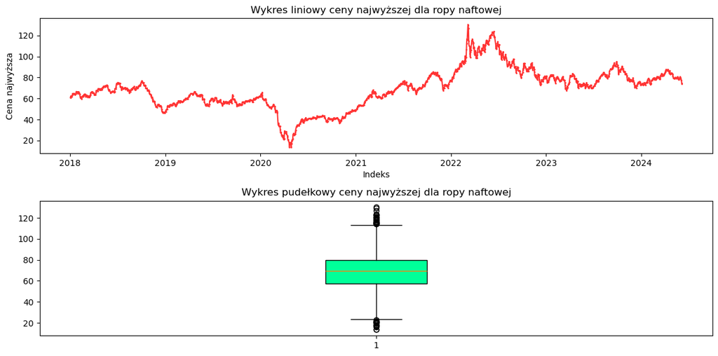

```python
plt.figure(figsize=(12,6))

# Wykres liniowy
plt.subplot(211)
plt.plot(oil.High, color='#FF3333', linestyle='-', marker='o', markersize=1)
plt.title('Wykres liniowy ceny najwyższej dla ropy naftowej')
plt.xlabel('Indeks')
plt.ylabel('Cena najwyższa')

# Wykres pudełkowy
plt.subplot(212)
plt.boxplot(oil.High, patch_artist=True, boxprops=dict(facecolor='#00FF99')) # Zmiana koloru pudełek i tła
plt.title('Wykres pudełkowy ceny najwyższej dla ropy naftowej')

plt.tight_layout()
plt.show()
```

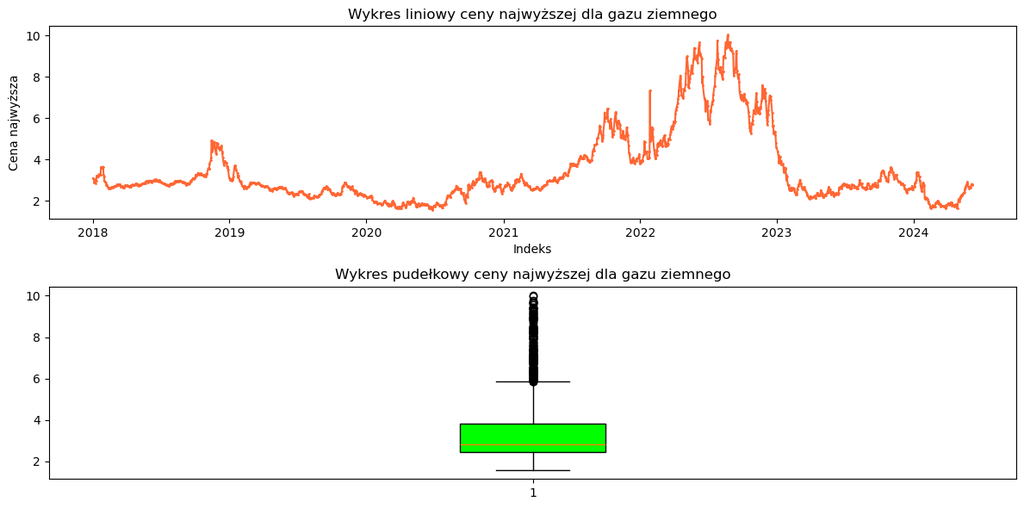

```python
plt.figure(figsize=(12,6))

# Wykres liniowy
plt.subplot(211)
plt.plot(gas.High, color='#FF6633', linestyle='-', marker='o', markersize=1) # Dodanie koloru, stylu linii i markerów
plt.title('Wykres liniowy ceny najwyższej dla gazu ziemnego')
plt.xlabel('Indeks')
plt.ylabel('Cena najwyższa')

# Wykres pudełkowy
plt.subplot(212)
plt.boxplot(gas.High, patch_artist=True, boxprops=dict(facecolor='#00FF00')) # Zmiana koloru pudełek i tła
plt.title('Wykres pudełkowy ceny najwyższej dla gazu ziemnego')

plt.tight_layout()
plt.show()
```

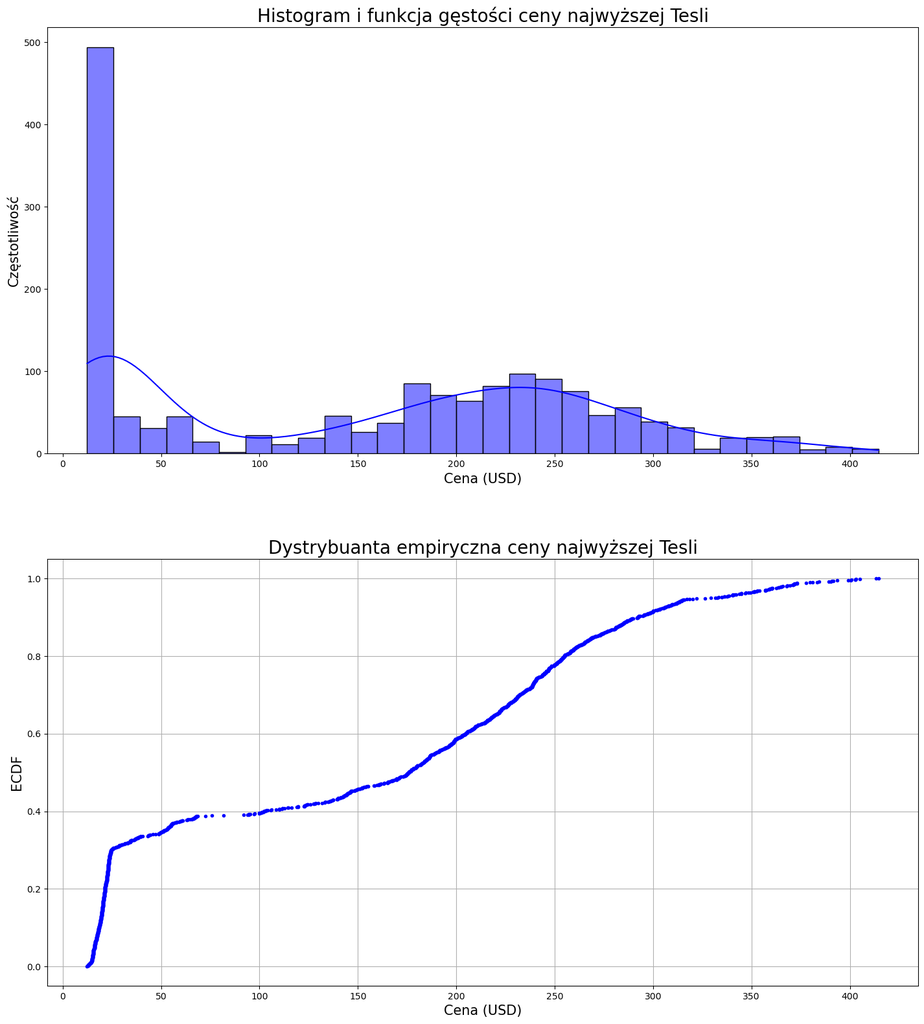

```python
# Histogram i funkcja gęstości dla cen Tesli
plt.figure(figsize=(30, 25))

# Histogram i funkcja gęstości dla cen Tesli
plt.subplot(321)
sns.histplot(data['Tesla_High'], bins=30, kde=True, color='blue')
plt.title('Histogram i funkcja gęstości ceny najwyższej Tesli', fontsize=20)
plt.xlabel('Cena (USD)', fontsize=15)
plt.ylabel('Częstotliwość', fontsize=15)

# ECDF dla cen Tesli
plt.subplot(323)
ecdf_tesla = ECDF(data['Tesla_High'])
plt.plot(ecdf_tesla.x, ecdf_tesla.y, marker='.', linestyle='none', color='blue')
plt.title('Dystrybuanta empiryczna ceny najwyższej Tesli', fontsize=20)
plt.xlabel('Cena (USD)', fontsize=15)
plt.ylabel('ECDF', fontsize=15)
plt.grid(True)

plt.tight_layout(pad=6)
plt.show()
```

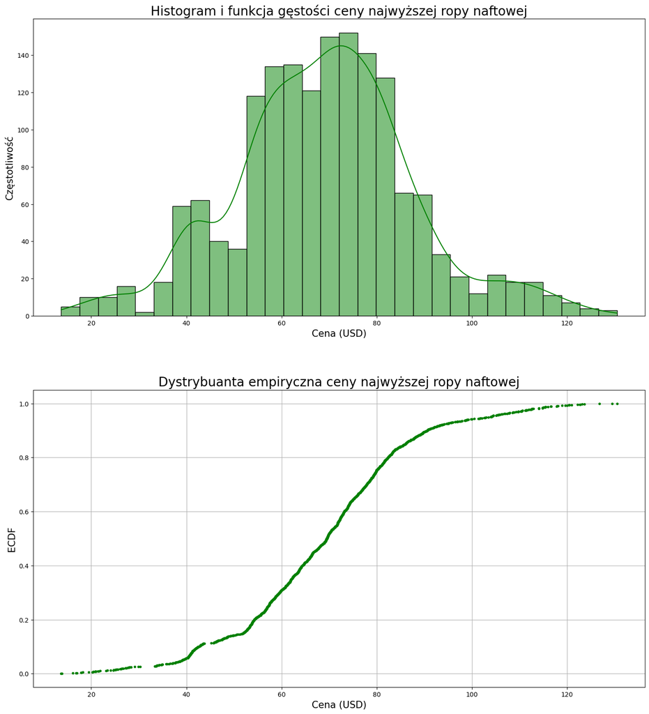

```python
# Histogram i funkcja gęstości dla cen ropy naftowej
plt.figure(figsize=(30, 25))

# Histogram i funkcja gęstości dla cen ropy naftowej
plt.subplot(323)
sns.histplot(data['Oil_High'], bins=30, kde=True, color='green')
plt.title('Histogram i funkcja gęstości ceny najwyższej ropy naftowej', fontsize=20)
plt.xlabel('Cena (USD)', fontsize=15)
plt.ylabel('Częstotliwość', fontsize=15)

# ECDF dla cen ropy naftowej
plt.subplot(325)
ecdf_oil = ECDF(data['Oil_High'])
plt.plot(ecdf_oil.x, ecdf_oil.y, marker='.', linestyle='none', color='green')
plt.title('Dystrybuanta empiryczna ceny najwyższej ropy naftowej', fontsize=20)
plt.xlabel('Cena (USD)', fontsize=15)
plt.ylabel('ECDF', fontsize=15)
plt.grid(True)

plt.tight_layout(pad=6)
plt.show()
```

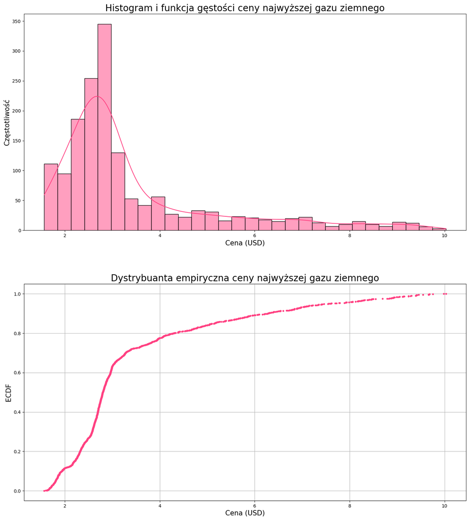

```python
# Histogram i funkcja gęstości dla cen gazu ziemnego
plt.figure(figsize=(30, 25))

# Histogram i funkcja gęstości dla cen gazu ziemnego
plt.subplot(321)
sns.histplot(data['Gas_High'], bins=30, kde=True, color='#FF4081')
plt.title('Histogram i funkcja gęstości ceny najwyższej gazu ziemnego', fontsize=20)
plt.xlabel('Cena (USD)', fontsize=15)
plt.ylabel('Częstotliwość', fontsize=15)

# ECDF dla cen gazu ziemnego
plt.subplot(323)
ecdf_gas = ECDF(data['Gas_High'])
plt.plot(ecdf_gas.x, ecdf_gas.y, marker='.', linestyle='none', color='#FF4081')
plt.title('Dystrybuanta empiryczna ceny najwyższej gazu ziemnego', fontsize=20)
plt.xlabel('Cena (USD)', fontsize=15)
plt.ylabel('ECDF', fontsize=15)
plt.grid(True)

plt.tight_layout(pad=6)
plt.show()
```

**Podstawowe statystyki**

Obliczono podstawowe statystyki dla cen akcji Tesli, ropy naftowej i gazu ziemnego, takie jak:

```python
# Tworzenie tabeli statystyk opisowych dla każdego z analizowanych zbiorów danych
stats_df = pd.DataFrame({
    'Tesla': tesla['High'].describe(),
    'Crude Oil': oil['High'].describe(),
    'Natural Gas': gas['High'].describe()
})

kurtosis_values = {
    'Tesla': tesla['High'].kurtosis(),
    'Crude Oil': oil['High'].kurtosis(),
    'Natural Gas': gas['High'].kurtosis()
}

skewness_values = {
    'Tesla': tesla['High'].skew(),
    'Crude Oil': oil['High'].skew(),
    'Natural Gas': gas['High'].skew()
}

# Dodawanie kurtózy i skośności do tabeli statystyk
stats_df.loc['kurtosis'] = kurtosis_values
stats_df.loc['skewness'] = skewness_values

# Transponowanie tabeli
stats_df = stats_df.transpose()

# Wyświetlanie tabeli
print(stats_df)
```

```
              count        mean         std        min        25%         50%  \
Tesla        1617.0  151.940379  112.754532  12.445333  23.140667  175.880005
Crude Oil    1618.0   68.872083   18.860783  13.690000  57.252500   69.524998
Natural Gas  1618.0    3.453914    1.749359   1.567000   2.442000    2.800000

                    75%         max  kurtosis  skewness
Tesla        243.623337  414.496674 -1.314904  0.116717
Crude Oil     79.900002  130.500000  0.468128  0.109696
Natural Gas    3.806750   10.028000  2.524137  1.770790
```

**Regresja liniowa**

Przeprowadzono regresję liniową, aby zbadać związek między cenami akcji Tesli a cenami ropy naftowej i gazu ziemnego. Model regresji liniowej pozwolił na ocenę siły i kierunku tych zależności.

```python
# Regresja liniowa: Tesla ~ Oil + Gas
X = data[['Oil_High', 'Gas_High']]
X = sm.add_constant(X)  # Dodanie stałej (intercept)
y = data['Tesla_High']

model = sm.OLS(y, X).fit()
print(model.summary())
```

```
                            OLS Regression Results
==============================================================================
Dep. Variable:             Tesla_High   R-squared:                       0.371
Model:                            OLS   Adj. R-squared:                  0.371
Method:                 Least Squares   F-statistic:                     476.7
Date:                Mon, 10 Jun 2024   Prob (F-statistic):          2.03e-163
Time:                        07:04:16   Log-Likelihood:                -9559.3
No. Observations:                1617   AIC:                         1.912e+04
Df Residuals:                    1614   BIC:                         1.914e+04
Df Model:                           2
Covariance Type:            nonrobust
==============================================================================
                 coef    std err          t      P>|t|      [0.025      0.975]
------------------------------------------------------------------------------
const        -80.2485      8.508     -9.433      0.000     -96.936     -63.561
Oil_High       2.6866      0.156     17.252      0.000       2.381       2.992
Gas_High      13.6557      1.679      8.134      0.000      10.363      16.949
==============================================================================
Omnibus:                      432.305   Durbin-Watson:                   0.008
Prob(Omnibus):                  0.000   Jarque-Bera (JB):               76.366
Skew:                           0.125   Prob(JB):                     2.61e-17
Kurtosis:                       1.965   Cond. No.                         274.
==============================================================================

Notes:
[1] Standard Errors assume that the covariance matrix of the errors is correctly specified.
```

**Analiza składników reszt**

Analiza składników reszt obejmowała:

```python
import statsmodels.api as sm
import scipy.stats as stats

# Składniki reszt
residuals = model.resid
```

**Wykres gęstości składników reszt**

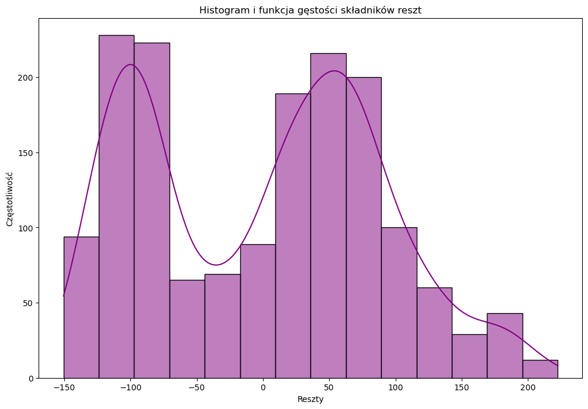

```python
plt.figure(figsize=(12, 8))
sns.histplot(residuals, kde=True, color='purple')
plt.title('Histogram i funkcja gęstości składników reszt')
plt.xlabel('Reszty')
plt.ylabel('Częstotliwość')
plt.show()
```

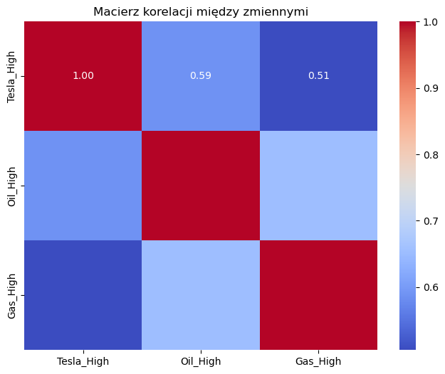

```python
correlation_matrix = data[['Tesla_High', 'Oil_High', 'Gas_High']].corr()
plt.figure(figsize=(8, 6))
sns.heatmap(correlation_matrix, annot=True, cmap='coolwarm', fmt=".2f")
plt.title('Macierz korelacji między zmiennymi')
plt.show()
```

**Testy normalności Shapiro-Wilka, Kołmogorowa-Smirnova, Andersona-Darlinga, D'Agostino-Pearsona i T-Czuprowa dla reszt**

```python
normality_tests = {
    'Shapiro-Wilk': stats.shapiro(residuals),
    'Kolmogorov-Smirnov': stats.kstest(residuals, 'norm'),
    'Anderson-Darling': stats.anderson(residuals, dist='norm'),
    "D'Agostino-Pearson": stats.normaltest(residuals),
    'Tschuprow': stats.kurtosistest(residuals)
}

print("Testy normalności składników reszt:")
for test, result in normality_tests.items():
    if test == 'Anderson-Darling':
        print(f"{test}: Statystyka={result.statistic}, p-value={result.critical_values[2]}")
    elif test == "D'Agostino-Pearson" or test == 'Tschuprow':
        print(f"{test}: Statystyka={result.statistic}, p-value={result.pvalue}")
    else:
        print(f"{test}: Statystyka={result.statistic}, p-value={result.pvalue}")
```

```
Testy normalności składników reszt:
Shapiro-Wilk: Statystyka=0.947595477104187, p-value=1.4894561637568446e-23
Kolmogorov-Smirnov: Statystyka=0.5448782332148219, p-value=0.0
Anderson-Darling: Statystyka=30.77950208977836, p-value=0.785
D'Agostino-Pearson: Statystyka=432.3051938646387, p-value=1.3369645846775908e-94
Tschuprow: Statystyka=-20.690693829753556, p-value=4.201243224624697e-95
```

**Wniosek z przeprowadzonych testów normalności składników reszt:**

Ogólnie rzecz biorąc, wyniki wskazują na to, że składniki reszt nie spełniają założeń o normalności, co może sugerować potrzebę dalszej analizy lub dostosowania modelu regresji.

**Wykresy QQ (kwantylowo-kwantylowe)**

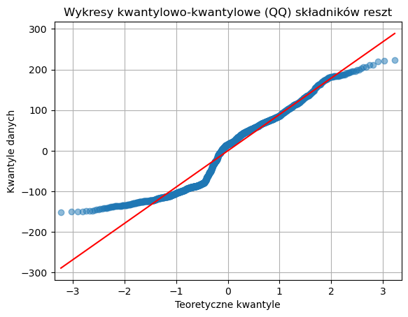

```python
plt.figure(figsize=(10, 6))
sm.qqplot(residuals, line='s', marker='o', alpha=0.5)
plt.title('Wykresy kwantylowo-kwantylowe (QQ) składników reszt')
plt.xlabel('Teoretyczne kwantyle')
plt.ylabel('Kwantyle danych')
plt.grid(True)
plt.show()
```

**Podsumowanie**

Projekt ten dostarcza wglądu w zależności między cenami akcji Tesli a cenami ropy naftowej i gazu ziemnego w latach 2018-2024, używając zaawansowanych technik analizy danych i wizualizacji. Analiza może być użyteczna dla inwestorów oraz osób zainteresowanych rynkiem finansowym, dostarczając cennych informacji na temat wpływu cen surowców energetycznych na ceny akcji.